# Are we more civilized today?

Marie Højlund Christiansen

Updated 2023-01-06

This exercise is based on the dataset provided by [OurWorldInData project](https://ourworldindata.org/homicides) based at the Oxford University.

## The long-term trend in Homicides in Western Europe

**Are homicide rates in Europe today lower or higher than in the past? Using the provided dataset, display and describe the long-run homicide rates for the five European regions: Italy, England, Germany, Netherlands and Scandinavia.**

I begin by loading library:

```r
library(tidyverse)
```

### Load the available data

I load the data available from ourworldindata.org:

```r
Western_Europe <- read_csv("data/homicide-rates-across-western-europe.csv")
```

### Inspect the data

I inspect the data:

```r
head(Western_Europe)
```

```
## # A tibble: 6 × 4
##   Entity  Code   Year Homicide rate in Europe over long-term (per 100,000) (ho…¹
##   <chr>   <chr> <dbl>                                                      <dbl>
## 1 England <NA>   1300                                                         23
## 2 England <NA>   1550                                                          7
## 3 England <NA>   1625                                                          6
## 4 England <NA>   1675                                                          4
## 5 England <NA>   1725                                                          2
## 6 England <NA>   1775                                                          1
## # … with abbreviated variable name
## #   ¹`Homicide rate in Europe over long-term (per 100,000) (homicides per 100,000 people)`
```

```r
tail(Western_Europe)
```

```
## # A tibble: 6 × 4
##   Entity      Code   Year Homicide rate in Europe over long-term (per 100,000)…¹
##   <chr>       <chr> <dbl>                                                  <dbl>
## 1 Scandinavia <NA>   2011                                                    1.1
## 2 Scandinavia <NA>   2012                                                    1.1
## 3 Scandinavia <NA>   2013                                                    1
## 4 Scandinavia <NA>   2014                                                    1
## 5 Scandinavia <NA>   2015                                                    1
## 6 Scandinavia <NA>   2016                                                    1
## # … with abbreviated variable name
## #   ¹`Homicide rate in Europe over long-term (per 100,000) (homicides per 100,000 people)`
```

The column `Homicide rate in Europe over long-term (per 100,000)` is not very easy to work with, so I change its name to `homicides_per_100k` by using the function `names()`:

```r
#Checking column names
colnames(Western_Europe)
```

```
## [1] "Entity"
## [2] "Code"
## [3] "Year"
## [4] "Homicide rate in Europe over long-term (per 100,000) (homicides per 100,000 people)"
```

```r
#Renaming column
names(Western_Europe)[4] ="homicides_per_100k"

#Checking column names again
colnames(Western_Europe)
```

```
## [1] "Entity"             "Code"               "Year"
## [4] "homicides_per_100k"
```

After having inspected the data and changed the column name `Homicide rate in Europe over long-term (per 100,000)` to something easier to work with, I move on to what big picture the data contains.

## Long-term trend in homicides

I use the `ggplot` function to plot the homicide data. I load `Year`on the x axis and `homicides_per_100k`on the y axis. I provide the plot with meaningful title and axis labels:

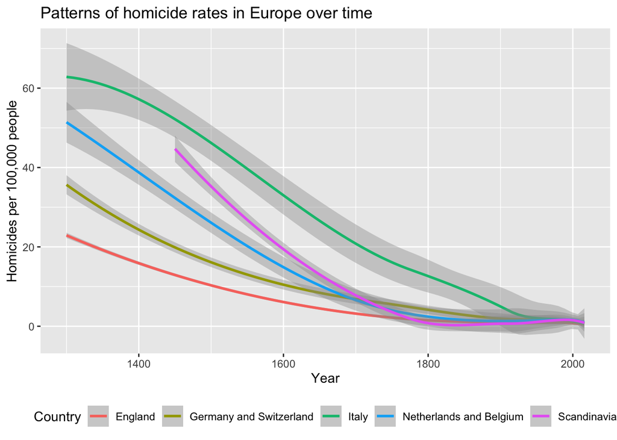

```r
ggplot(data = Western_Europe, aes(x = Year, y = homicides_per_100k, color = Entity)) +
  geom_smooth() +
  ggtitle("Patterns of homicide rates in Europe over time") +
  xlab("Year") +
  ylab("Homicides per 100,000 people") +
  theme(legend.position = "bottom") +
  scale_color_discrete("Country")
```

What we can see from the `ggplot`is that the homicide rates in all 5 countries are descending over time. However, the visualization is not very clear. I move on to check the rates for individual countries.

### Uncouple the homicides of individual countries

I reuse the `ggplot`from the chunk above and insert the `facet_wrap()` function to split the countries into individual charts. I change the facet layout to two columns and three rows so the trends are easier to access in horizontal layout:

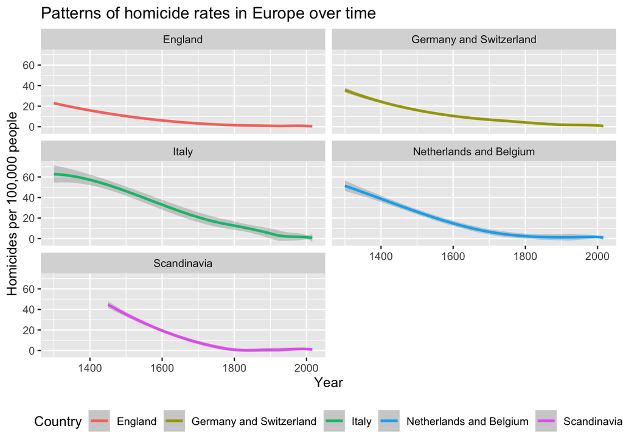

```r
ggplot(data = Western_Europe, aes(x = Year, y = homicides_per_100k, color = Entity)) +
  geom_smooth() +
  ggtitle("Patterns of homicide rates in Europe over time") +
  xlab("Year") +
  ylab("Homicides per 100,000 people") +
  theme(legend.position = "bottom") +
  scale_color_discrete("Country") +
  facet_wrap(~ Entity, ncol = 2, nrow = 3)
```

This is an easier accessible visualization. I move on to comparing the trends in homicide with the pattern of reign duration among Danish rulers over time.

## Compare the trends in homicide with the pattern of reign duration among Danish rulers through time.

I make a `ggplot`of the kings data. I create a midyear column to have a consistent way of plotting the rulers’ reign on the x axis. I plot the rulers’ reign duration on the y axis. I provide the plot with title and axis labels:

```r
#Loading existing kings data set
kings <- read_delim("data/kings.csv", ";", escape_double = FALSE,
    trim_ws = TRUE)
#Inspecting data
kings
```

```
## # A tibble: 47 × 4
##    Kings                  Start_date End_date Yearasruler
##    <chr>                       <dbl>    <dbl> <chr>
##  1 "Gorm den Gamle"               NA       NA Unknown
##  2 "Harald 1. Bl\xe5tand"         NA       NA Unknown
##  3 "Svend 1. Tvesk\xe6g"          NA       NA Unknown
##  4 "Harald 2."                  1014     1018 4
##  5 "Knud 1. den Store"          1018     1035 17
##  6 "Hardeknud"                  1035     1042 7
##  7 "Magnus den Gode"            1042     1047 5
##  8 "Svend 2. Estridsen"         1047     1074 27
##  9 "Harald 3. Hen"              1074     1080 6
## 10 "Knud 2. den Hellige"        1080     1086 6
## # … with 37 more rows
```

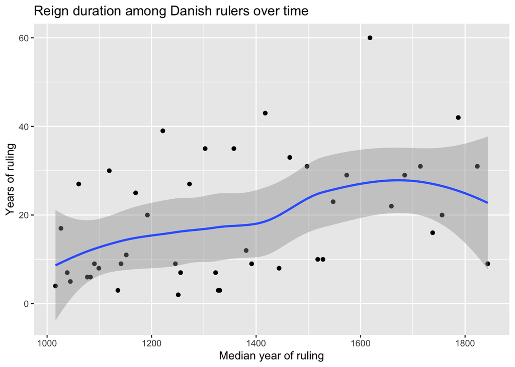

```r
#Cleaning the data
#Removing NA values
#Turn values in Yearasruler column numeric
kings <- na.omit(kings)
kings$Yearasruler <-  as.numeric(kings$Yearasruler)

#Creating a midyear column
kings <- kings %>%
  mutate(midyear= (End_date - (End_date - Start_date)/2))

#ggplot plotting midyear on x axis and duration on y axis
ggplot(kings,  aes(midyear, Yearasruler)) +
  geom_point()+
  geom_smooth()+
  xlab("Median year of ruling")+
  ylab("Years of ruling")+
  ggtitle("Reign duration among Danish rulers over time")
```

**How would you characterize the trend compared to the homicides above?**

**Answer:** While the pattern trends in the homicide rates visualizations above are descending over time, the pattern trend of the Danish monarch’s reign duration increases in this visualization. This means that the monarchs’ periods of reign have become longer as time has passed as the rates of homicides committed in European countries have decreased as time has passed. However, the two plots visualize different periods of historical time (year 1300-2000 in the homicide plot and year 1000-1800 in the kings plot), which makes comparison more difficult.

## Final tasks

**1) Plot: In the faceted plot above, move the legend from the current position on the side to below the facets, and label it “Country” instead of “Entity”.**

**Answer:** Please check out the changes in the plot above.

**2) Rmarkdown:**

- edit the author of the document, and convert ‘Final Tasks’ into heading #2 (like the other headings)
- add a `floating table of contents` to your Rmarkdown document,
- provide informative `chunk-names` and edit flags in your R chunks, and
- automatically generate a `timestamp` to show when the document was last updated. (Hint: check the Rmarkdown episode in our Data Carpentry tutorial)

**Answer:** Please check out the changes in the document.

**3) Question: In <250 words articulate your answer on the basis of the data visualizations to the following question: Are we more civilized today?**

**Answer:** In specific relation to the above visualized descending homicide rate patterns in European history, European countries seem more civilized today than back in the days. However, being *civilized* does not only refer to the rate of committed - it refers to much else besides homicide rates. People behaving *civilized* are being polite and behave in a calm and reasonable way. Societies defined as *civilized* have well developed government systems, cultures, and ways of living. The descending European homicide rates imply that government and justice systems have been developed over time - why the countries can be said to have become more civilized. So yes, we have become more *civilized* in relation to homicide rates, but *civilized* refers to more besides these rates.